# Machine Learning Hackathon

Problem Statement You are hired as a data scientist at a leading shopping mall in the country. The shopping mall has tied up with different restaurants/bars to provide discount coupons to all its customers. The coupons increase the footfalls at these restaurants and help the shopping mall to attract more customers. The organization has been relying upon simple guidelines to determine what coupons are to be provided to the customers, however, the organization feels that they need a more robust model to determine whether a customer will accept the recommended coupon or not to improve the use rate. The organization plans to use a mix of client's details that they have captured to create this model. You are provided with the historical data of the recommended coupons along with customer details in the previous years and your task is to come up with a model which would be able to predict whether a customer will accept the recommended coupon

```python
#Regular Libraries
import numpy as np
import pandas as pd
import matplotlib.pyplot as plt
%matplotlib inline
import seaborn as sns
```

```python
#ML libraries
from sklearn.model_selection import train_test_split
from sklearn.model_selection import cross_val_score, cross_validate, RandomizedSearchCV, GridSearchCV


#For Model Building
from sklearn.linear_model import LogisticRegression
from sklearn import svm
from sklearn.svm import SVC
from sklearn.naive_bayes import GaussianNB
from sklearn.tree import DecisionTreeClassifier
from sklearn.ensemble import RandomForestClassifier
from sklearn.neighbors import KNeighborsClassifier
from sklearn.ensemble import AdaBoostClassifier

#For obtaining performance metrics


#For Model Building
from sklearn.linear_model import LogisticRegression
from sklearn.tree import DecisionTreeClassifier
from sklearn.ensemble import RandomForestClassifier
from sklearn.svm import SVC
```

```python
import warnings
warnings.filterwarnings("ignore")
```

## Read the Data

```python
#1. Load the train data
data_train = pd.read_csv('train.csv')
print("Shape of the Train Data:", data_train.shape)
data_train.head()
```

```
Shape of the Train Data: (10147, 27)
```

|  | customer_id | destination | passanger | weather | temperature | time | coupon | expiration | gender | age | ... | CoffeeHouse | CarryAway | RestaurantLessThan20 | Restaurant20To50 | toCoupon_GEQ5min | toCoupon_GEQ15min | toCoupon_GEQ25min | direction_same | direction_opp | Y |
| --- | --- | --- | --- | --- | --- | --- | --- | --- | --- | --- | --- | --- | --- | --- | --- | --- | --- | --- | --- | --- | --- |
| 0 | 258868 | No Urgent Place | Friend(s) | Sunny | 80 | 6PM | Restaurant(<20) | 1d | Male | 21 | ... | 1~3 | 4~8 | 4~8 | never | 1 | 1 | 0 | 0 | 1 | 1 |
| 1 | 318369 | Work | Alone | Sunny | 80 | 7AM | Restaurant(<20) | 2h | Male | 21 | ... | 1~3 | 4~8 | 1~3 | less1 | 1 | 0 | 0 | 1 | 0 | 0 |
| 2 | 320906 | No Urgent Place | Alone | Sunny | 80 | 10AM | Coffee House | 2h | Female | 21 | ... | gt8 | 4~8 | 1~3 | 1~3 | 1 | 1 | 0 | 0 | 1 | 0 |
| 3 | 412393 | Work | Alone | Rainy | 55 | 7AM | Restaurant(<20) | 2h | Female | 26 | ... | less1 | 4~8 | 1~3 | never | 1 | 1 | 1 | 0 | 1 | 0 |
| 4 | 290854 | Home | Alone | Snowy | 30 | 6PM | Coffee House | 1d | Male | 31 | ... | less1 | 4~8 | less1 | never | 1 | 1 | 0 | 0 | 1 | 0 |

5 rows × 27 columns

```python
#load the test data-set
data_test = pd.read_csv('test.csv')
print("Shape of the Test Data:", data_test.shape)
data_test.head()
```

```
Shape of the Test Data: (2537, 26)
```

|  | customer_id | destination | passanger | weather | temperature | time | coupon | expiration | gender | age | ... | Bar | CoffeeHouse | CarryAway | RestaurantLessThan20 | Restaurant20To50 | toCoupon_GEQ5min | toCoupon_GEQ15min | toCoupon_GEQ25min | direction_same | direction_opp |
| --- | --- | --- | --- | --- | --- | --- | --- | --- | --- | --- | --- | --- | --- | --- | --- | --- | --- | --- | --- | --- | --- |
| 0 | 374679 | No Urgent Place | Friend(s) | Sunny | 80 | 6PM | Coffee House | 1d | Female | below21 | ... | never | 1~3 | less1 | 4~8 | less1 | 1 | 0 | 0 | 0 | 1 |
| 1 | 469678 | Home | Alone | Sunny | 80 | 6PM | Carry out & Take away | 2h | Male | 21 | ... | 1~3 | never | gt8 | 4~8 | 1~3 | 1 | 1 | 0 | 1 | 0 |
| 2 | 216140 | No Urgent Place | Alone | Rainy | 55 | 10AM | Coffee House | 1d | Female | 26 | ... | never | never | 1~3 | less1 | never | 1 | 1 | 0 | 0 | 1 |
| 3 | 184301 | No Urgent Place | Partner | Sunny | 80 | 6PM | Bar | 1d | Male | 50plus | ... | never | 4~8 | 4~8 | 1~3 | less1 | 1 | 1 | 0 | 0 | 1 |
| 4 | 148720 | Work | Alone | Sunny | 30 | 7AM | Carry out & Take away | 1d | Female | 26 | ... | never | never | 1~3 | 4~8 | less1 | 1 | 1 | 0 | 0 | 1 |

5 rows × 26 columns

```python
#no of Features is 26 and Target Column is Y
target_col = 'Y'
len(data_train.columns.drop(target_col))
```

```
26
```

## Data Cleaning

```python
#2.Check for data completeness
data_train.info()
```

```
<class 'pandas.core.frame.DataFrame'>
RangeIndex: 10147 entries, 0 to 10146
Data columns (total 27 columns):
 #   Column                Non-Null Count  Dtype
---  ------                --------------  -----
 0   customer_id           10147 non-null  int64
 1   destination           10147 non-null  object
 2   passanger             10147 non-null  object
 3   weather               10147 non-null  object
 4   temperature           10147 non-null  int64
 5   time                  10147 non-null  object
 6   coupon                10147 non-null  object
 7   expiration            10147 non-null  object
 8   gender                10147 non-null  object
 9   age                   10147 non-null  object
```

[output cut: 19 more lines]

```python
# Time converting to Integer values by using date time format
data_train['time'] = pd.to_datetime(data_train['time'],format = '%I%p').dt.hour
data_test['time'] = pd.to_datetime(data_test['time'],format = '%I%p').dt.hour
```

```python
data_train.info()
```

```
<class 'pandas.core.frame.DataFrame'>
RangeIndex: 10147 entries, 0 to 10146
Data columns (total 27 columns):
 #   Column                Non-Null Count  Dtype
---  ------                --------------  -----
 0   customer_id           10147 non-null  int64
 1   destination           10147 non-null  object
 2   passanger             10147 non-null  object
 3   weather               10147 non-null  object
 4   temperature           10147 non-null  int64
 5   time                  10147 non-null  int64
 6   coupon                10147 non-null  object
 7   expiration            10147 non-null  object
 8   gender                10147 non-null  object
 9   age                   10147 non-null  object
```

[output cut: 19 more lines]

```python
# drop the Car column because it has less then 1% values only
data_train.drop(columns = 'car', axis=1, inplace = True)
data_test.drop(columns = 'car', axis=1, inplace = True)
```

```python
#3. Deal with Missing data
#
#Missing value in the Data-Set
data_train.isna().sum()
```

```
customer_id               0
destination               0
passanger                 0
weather                   0
temperature               0
time                      0
coupon                    0
expiration                0
gender                    0
age                       0
maritalStatus             0
has_children              0
education                 0
occupation                0
income                    0
Bar                      88
CoffeeHouse             172
CarryAway               122
RestaurantLessThan20     97
Restaurant20To50        148
toCoupon_GEQ5min          0
toCoupon_GEQ15min         0
toCoupon_GEQ25min         0
direction_same            0
direction_opp             0
Y                         0
dtype: int64
```

```python
#Checking for unique values in categorical columns
for i in data_train.columns:
    if data_train[i].dtype == type(object):
        print(i,end=': ')
        print('\n',data_train[i].unique())
        print()
```

```
destination:
 ['No Urgent Place' 'Work' 'Home']

passanger:
 ['Friend(s)' 'Alone' 'Partner' 'Kid(s)']

weather:
 ['Sunny' 'Rainy' 'Snowy']

coupon:
 ['Restaurant(<20)' 'Coffee House' 'Restaurant(20-50)' 'Bar'
 'Carry out & Take away']

expiration:
 ['1d' '2h']

gender:
 ['Male' 'Female']

age:
 ['21' '26' '31' '50plus' '36' '41' '46' 'below21']

maritalStatus:
 ['Unmarried partner' 'Single' 'Married partner' 'Divorced' 'Widowed']

education:
 ['Some college - no degree' 'Bachelors degree'
 'Graduate degree (Masters or Doctorate)' 'Associates degree'
 'High School Graduate' 'Some High School']

occupation:
 ['Student' 'Computer & Mathematical' 'Unemployed' 'Healthcare Support'
 'Retired' 'Food Preparation & Serving Related' 'Sales & Related'
 'Architecture & Engineering' 'Education&Training&Library'
 'Arts Design Entertainment Sports & Media' 'Management'
 'Community & Social Services' 'Life Physical Social Science'
 'Transportation & Material Moving' 'Farming Fishing & Forestry'
 'Business & Financial' 'Office & Administrative Support' 'Legal'
 'Personal Care & Service' 'Healthcare Practitioners & Technical'
 'Protective Service' 'Building & Grounds Cleaning & Maintenance'
 'Production Occupations' 'Installation Maintenance & Repair'
 'Construction & Extraction']

income:
 ['Less than $12500' '$37500 - $49999' '$25000 - $37499' '$12500 - $24999'
 '$50000 - $62499' '$62500 - $74999' '$87500 - $99999' '$100000 or More'
 '$75000 - $87499']

Bar:
 ['less1' '1~3' 'never' '4~8' 'gt8' nan]

CoffeeHouse:
 ['1~3' 'gt8' 'less1' 'never' '4~8' nan]

CarryAway:
 ['4~8' '1~3' 'gt8' 'less1' 'never' nan]

RestaurantLessThan20:
 ['4~8' '1~3' 'less1' 'gt8' nan 'never']

Restaurant20To50:
 ['never' 'less1' '1~3' '4~8' 'gt8' nan]
```

```python
# Mode Imputation of Missing Values for Categorical Variables
Bar_Mode = data_train["Bar"].mode()[0]
CoffeeHouse_Mode = data_train["CoffeeHouse"].mode()[0]
CarryAway_Mode = data_train["CarryAway"].mode()[0]
RestaurantLessThan20_Mode = data_train["RestaurantLessThan20"].mode()[0]
Restaurant20To50_Mode = data_train["Restaurant20To50"].mode()[0]

#Train-Data
data_train["Bar"] = data_train["Bar"].fillna(Bar_Mode)
data_train["CoffeeHouse"] = data_train["CoffeeHouse"].fillna(CoffeeHouse_Mode)
data_train["CarryAway"] = data_train["CarryAway"].fillna(CarryAway_Mode)
data_train["RestaurantLessThan20"] = data_train["RestaurantLessThan20"].fillna(RestaurantLessThan20_Mode)
data_train["Restaurant20To50"] = data_train["Restaurant20To50"].fillna(Restaurant20To50_Mode)

#Test-Data
data_test["Bar"] = data_test["Bar"].fillna(Bar_Mode)
data_test["CoffeeHouse"] = data_test["CoffeeHouse"].fillna(CoffeeHouse_Mode)
data_test["CarryAway"] = data_test["CarryAway"].fillna(CarryAway_Mode)
data_test["RestaurantLessThan20"] = data_test["RestaurantLessThan20"].fillna(RestaurantLessThan20_Mode)
data_test["Restaurant20To50"] = data_train["Restaurant20To50"].fillna(Restaurant20To50_Mode)
```

```python
#Age column
data_train["age"].value_counts()
```

```
21         2133
26         2033
31         1636
50plus     1431
36         1065
41          879
46          538
below21     432
Name: age, dtype: int64
```

```python
# 50 plus and below 21 categories in the data can be converted to 51 and 20 respectively and the Age gets conevrted to Integer
data_train['age'] = data_train['age'].apply(lambda x: 51 if x == '50plus' else (20 if x=='below21' else x))
data_test['age'] = data_test['age'].apply(lambda x: 51 if x == '50plus' else (20 if x=='below21' else x))
```

```python
# Converting age to numerical data type
data_train['age'] = data_train['age'].astype('int64')
data_test['age'] = data_test['age'].astype('int64')
```

```python
data_train.info()
```

```
<class 'pandas.core.frame.DataFrame'>
RangeIndex: 10147 entries, 0 to 10146
Data columns (total 26 columns):
 #   Column                Non-Null Count  Dtype
---  ------                --------------  -----
 0   customer_id           10147 non-null  int64
 1   destination           10147 non-null  object
 2   passanger             10147 non-null  object
 3   weather               10147 non-null  object
 4   temperature           10147 non-null  int64
 5   time                  10147 non-null  int64
 6   coupon                10147 non-null  object
 7   expiration            10147 non-null  object
 8   gender                10147 non-null  object
 9   age                   10147 non-null  int64
```

[output cut: 18 more lines]

##### *Now There is no missing value in the Train & Test Data-Set

```python
#Numerical Columns
data_train._get_numeric_data()
```

|  | customer_id | temperature | time | age | has_children | toCoupon_GEQ5min | toCoupon_GEQ15min | toCoupon_GEQ25min | direction_same | direction_opp | Y |
| --- | --- | --- | --- | --- | --- | --- | --- | --- | --- | --- | --- |
| 0 | 258868 | 80 | 18 | 21 | 0 | 1 | 1 | 0 | 0 | 1 | 1 |
| 1 | 318369 | 80 | 7 | 21 | 0 | 1 | 0 | 0 | 1 | 0 | 0 |
| 2 | 320906 | 80 | 10 | 21 | 0 | 1 | 1 | 0 | 0 | 1 | 0 |
| 3 | 412393 | 55 | 7 | 26 | 0 | 1 | 1 | 1 | 0 | 1 | 0 |
| 4 | 290854 | 30 | 18 | 31 | 0 | 1 | 1 | 0 | 0 | 1 | 0 |
| ... | ... | ... | ... | ... | ... | ... | ... | ... | ... | ... | ... |
| 10142 | 201838 | 80 | 18 | 20 | 0 | 1 | 1 | 0 | 1 | 0 | 0 |
| 10143 | 248838 | 80 | 18 | 26 | 0 | 1 | 0 | 0 | 1 | 0 | 1 |
| 10144 | 173367 | 80 | 10 | 21 | 0 | 1 | 0 | 0 | 0 | 1 | 1 |
| 10145 | 488688 | 30 | 22 | 46 | 1 | 1 | 0 | 0 | 0 | 1 | 0 |
| 10146 | 431162 | 30 | 22 | 36 | 1 | 1 | 1 | 0 | 0 | 1 | 0 |

10147 rows × 11 columns

```python
#Categorical/Object Columns
data_train.describe(include='object')
```

|  | destination | passanger | weather | coupon | expiration | gender | maritalStatus | education | occupation | income | Bar | CoffeeHouse | CarryAway | RestaurantLessThan20 | Restaurant20To50 |
| --- | --- | --- | --- | --- | --- | --- | --- | --- | --- | --- | --- | --- | --- | --- | --- |
| count | 10147 | 10147 | 10147 | 10147 | 10147 | 10147 | 10147 | 10147 | 10147 | 10147 | 10147 | 10147 | 10147 | 10147 | 10147 |
| unique | 3 | 4 | 3 | 5 | 2 | 2 | 5 | 6 | 25 | 9 | 5 | 5 | 5 | 5 | 5 |
| top | No Urgent Place | Alone | Sunny | Coffee House | 1d | Female | Married partner | Bachelors degree | Unemployed | $25000 - $37499 | never | less1 | 1~3 | 1~3 | less1 |
| freq | 5045 | 5802 | 8015 | 3191 | 5643 | 5204 | 4086 | 3511 | 1485 | 1622 | 4238 | 2868 | 3863 | 4393 | 5037 |

## Univariate Analysis

### Target Variable = 'Y'

```python
#Checking the distribution of target variable in terms of percentage
data_train['Y'].value_counts(normalize=True)
```

```
1    0.568444
0    0.431556
Name: Y, dtype: float64
```

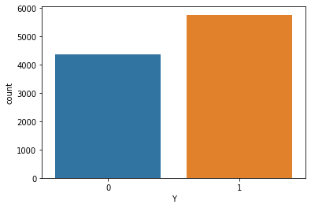

```python
sns.countplot(data_train['Y'])
```

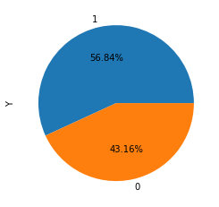

```python
data_train.Y.value_counts().plot.pie(autopct = '%.2f%%')
```

###### **It is clear that Target Variable 'Y' has 56.84% data with Category 1 (YES) and 43.16% with Category 0 (NO) - so that Train Data-set is mostly balanced for the given Target.

### Deep-Insight of destination

```python
#destination has 3 distinct values
data_train["destination"].value_counts()
```

```
No Urgent Place    5045
Home               2572
Work               2530
Name: destination, dtype: int64
```

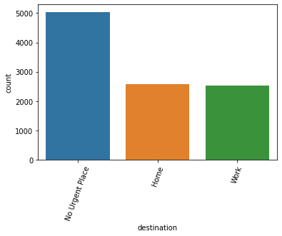

```python
#bar graph for destination
chart = sns.countplot(data_train["destination"], order = data_train["destination"].value_counts().index)
chart.set_xticklabels(chart.get_xticklabels(),rotation=70)
plt.figure(figsize=(10,5))
```

```python
# Check the outliers based on coupon usage (With in Y) in destination
destination = data_train[data_train['Y']==1]['destination'].value_counts()
print(destination.sum())
destination
```

```
5768
```

```
No Urgent Place    3198
Home               1299
Work               1271
Name: destination, dtype: int64
```

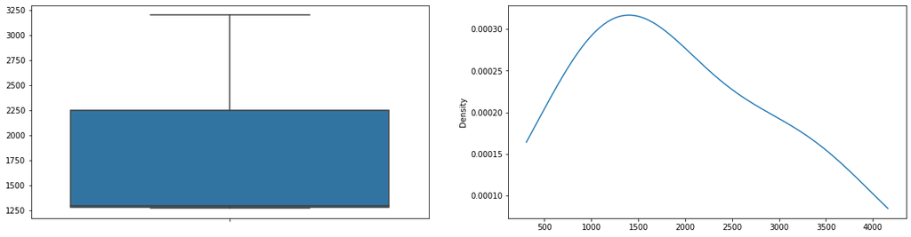

```python
fig, ax = plt.subplots(nrows=1, ncols=2, figsize=(20,5))
sns.boxplot(data=destination,y=destination.values, ax=ax[0])
destination.plot.kde(ax = ax[1])
```

```python
print(destination.skew())
```

```
1.7307987575468322
```

#### **Destination doesn;t have outliers, though there exists skewness

### Deep-Insight passanger

```python
#passanger has 4 distinct values
data_train["passanger"].value_counts()
```

```
Alone        5802
Friend(s)    2676
Partner       855
Kid(s)        814
Name: passanger, dtype: int64
```

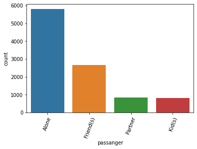

```python
chart = sns.countplot(data_train['passanger'], order = data_train['passanger'].value_counts().index)
chart.set_xticklabels(chart.get_xticklabels(),rotation=70)
plt.figure(figsize=(10,5))
```

```python
# Check the outliers based on coupon usage (With in Y) in passanger
passanger = data_train[data_train['Y']==1]['passanger'].value_counts()
print(passanger.sum())
passanger
```

```
5768
```

```
Alone        3049
Friend(s)    1800
Partner       510
Kid(s)        409
Name: passanger, dtype: int64
```

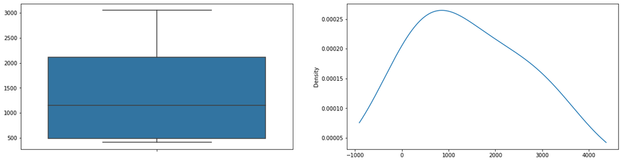

```python
fig, ax = plt.subplots(nrows=1, ncols=2, figsize=(20,5))
sns.boxplot(data=passanger,y=passanger.values, ax=ax[0])
passanger.plot.kde(ax = ax[1])
```

```python
print(passanger.skew())
```

```
0.7899972523633265
```

#### **Passanger doesn;t have outliers, though there exists skewness

### Deep-Insight of weather

```python
#weather has 3 distinct values
data_train["weather"].value_counts()
```

```
Sunny    8015
Snowy    1142
Rainy     990
Name: weather, dtype: int64
```

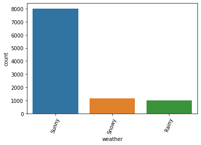

```python
chart = sns.countplot(data_train['weather'], order = data_train['weather'].value_counts().index)
chart.set_xticklabels(chart.get_xticklabels(),rotation=70)
plt.figure(figsize=(10,5))
```

```python
# Check the outliers based on coupon usage (With in Y) in weather
weather = data_train[data_train['Y']==1]['weather'].value_counts()
print(weather.sum())
weather
```

```
5768
```

```
Sunny    4757
Snowy     546
Rainy     465
Name: weather, dtype: int64
```

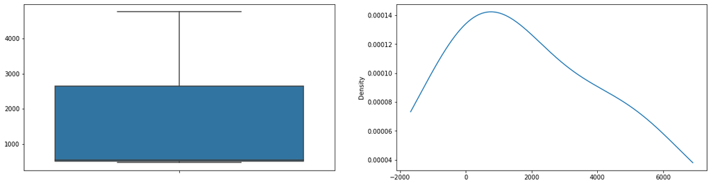

```python
fig, ax = plt.subplots(nrows=1, ncols=2, figsize=(20,5))
sns.boxplot(data=weather,y=weather.values, ax=ax[0])
weather.plot.kde(ax = ax[1])
```

```python
print(weather.skew())
```

```
1.7299297492720773
```

### Deep-Insight of coupon

```python
#coupon has 5 distinct values
data_train["coupon"].value_counts()
```

```
Coffee House             3191
Restaurant(<20)          2233
Carry out & Take away    1923
Bar                      1623
Restaurant(20-50)        1177
Name: coupon, dtype: int64
```

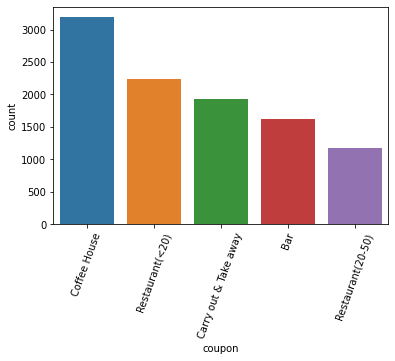

```python
chart = sns.countplot(data_train['coupon'], order = data_train['coupon'].value_counts().index)
chart.set_xticklabels(chart.get_xticklabels(),rotation=70)
plt.figure(figsize=(10,5))
```

```python
# Check the outliers based on coupon usage (With in Y) in coupon
coupon = data_train[data_train['Y']==1]['coupon'].value_counts()
print(coupon.sum())
coupon
```

```
5768
```

```
Coffee House             1600
Restaurant(<20)          1575
Carry out & Take away    1414
Bar                       664
Restaurant(20-50)         515
Name: coupon, dtype: int64
```

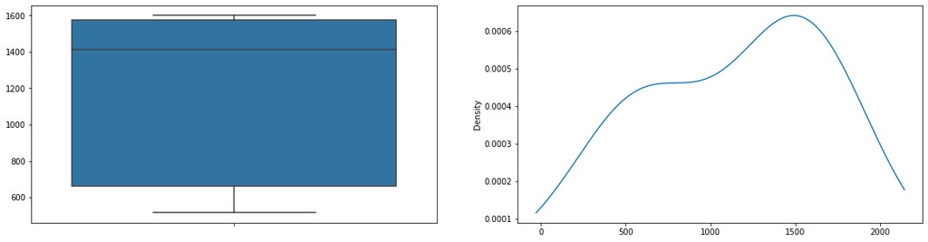

```python
fig, ax = plt.subplots(nrows=1, ncols=2, figsize=(20,5))
sns.boxplot(data=coupon,y=coupon.values, ax=ax[0])
coupon.plot.kde(ax = ax[1])
```

```python
print(coupon.skew())
```

```
-0.5734002084393751
```

#### **Coupon doesn;t have outliers, though there exists left skewnes

### Deep-Insight of expiration

```python
#expiration has 2 distinct values
data_train["expiration"].value_counts()
```

```
1d    5643
2h    4504
Name: expiration, dtype: int64
```

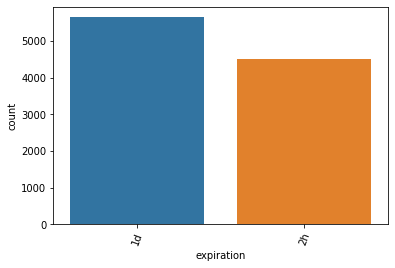

```python
chart = sns.countplot(data_train['expiration'], order = data_train['expiration'].value_counts().index)
chart.set_xticklabels(chart.get_xticklabels(),rotation=70)
plt.figure(figsize=(10,5))
```

### Deep-Insight of gender

```python
#gender has 2 distinct values
data_train["gender"].value_counts()
```

```
Female    5204
Male      4943
Name: gender, dtype: int64
```

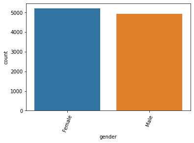

```python
chart = sns.countplot(data_train['gender'], order = data_train['gender'].value_counts().index)
chart.set_xticklabels(chart.get_xticklabels(),rotation=70)
plt.figure(figsize=(10,5))
```

### Deep-Insight of maritalStatus

```python
#maritalStatus has 5 distinct values
data_train["maritalStatus"].value_counts()
```

```
Married partner      4086
Single               3806
Unmarried partner    1737
Divorced              417
Widowed               101
Name: maritalStatus, dtype: int64
```

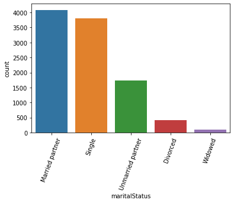

```python
chart = sns.countplot(data_train['maritalStatus'], order = data_train['maritalStatus'].value_counts().index)
chart.set_xticklabels(chart.get_xticklabels(),rotation=70)
plt.figure(figsize=(10,5))
```

```python
# Check the outliers based on maritalStatus usage (With in Y) in maritalStatus
maritalStatus = data_train[data_train['Y']==1]['maritalStatus'].value_counts()
print(maritalStatus.sum())
maritalStatus
```

```
5768
```

```
Single               2296
Married partner      2224
Unmarried partner     968
Divorced              232
Widowed                48
Name: maritalStatus, dtype: int64
```

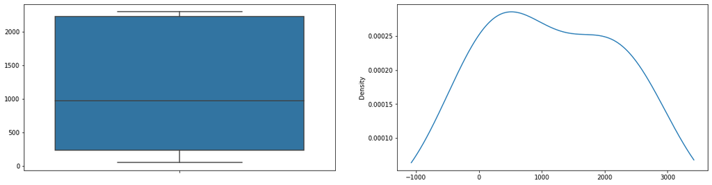

```python
fig, ax = plt.subplots(nrows=1, ncols=2, figsize=(20,5))
sns.boxplot(data=maritalStatus,y=maritalStatus.values, ax=ax[0])
maritalStatus.plot.kde(ax = ax[1])
```

```python
print(maritalStatus.skew())
```

```
0.1976308791571414
```

### Deep-Insight of education

```python
#education has 6 distinct values
data_train["education"].value_counts()
```

```
Bachelors degree                          3511
Some college - no degree                  3459
Graduate degree (Masters or Doctorate)    1477
Associates degree                          924
High School Graduate                       708
Some High School                            68
Name: education, dtype: int64
```

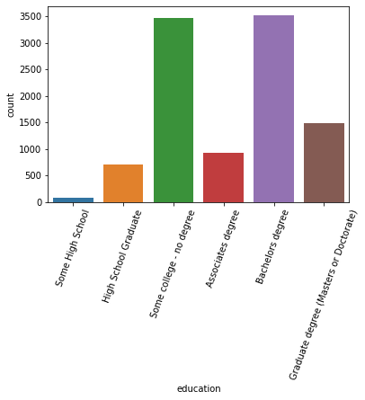

```python
education_order = ["Some High School", "High School Graduate", "Some college - no degree", "Associates degree", "Bachelors degree", "Graduate degree (Masters or Doctorate)"]
chart = sns.countplot(data_train['education'], order = education_order)
chart.set_xticklabels(chart.get_xticklabels(),rotation=70)
plt.figure(figsize=(10,5))
```

```python
# Check the outliers based on education usage (With in Y) in education
education = data_train[data_train['Y']==1]['education'].value_counts()
print(education.sum())
education
```

```
5768
```

```
Some college - no degree                  2069
Bachelors degree                          1948
Graduate degree (Masters or Doctorate)     781
Associates degree                          505
High School Graduate                       412
Some High School                            53
Name: education, dtype: int64
```

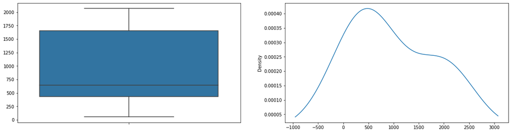

```python
fig, ax = plt.subplots(nrows=1, ncols=2, figsize=(20,5))
sns.boxplot(data=education,y=education.values, ax=ax[0])
education.plot.kde(ax = ax[1])
```

```python
print(education.skew())
```

```
0.6486777732125808
```

### Deep-Insight of Occupation

```python
#Occupation has 25 distinct values
data_train["occupation"].value_counts()
```

```
Unemployed                                   1485
Student                                      1245
Computer & Mathematical                      1111
Sales & Related                               896
Education&Training&Library                    753
Management                                    665
Arts Design Entertainment Sports & Media      526
Office & Administrative Support               517
Business & Financial                          433
Retired                                       394
Food Preparation & Serving Related            241
Healthcare Practitioners & Technical          205
Community & Social Services                   198
Healthcare Support                            186
Legal                                         179
Transportation & Material Moving              177
Life Physical Social Science                  140
Architecture & Engineering                    139
Personal Care & Service                       137
Protective Service                            135
Construction & Extraction                     118
Installation Maintenance & Repair             105
Production Occupations                         89
Building & Grounds Cleaning & Maintenance      37
Farming Fishing & Forestry                     36
Name: occupation, dtype: int64
```

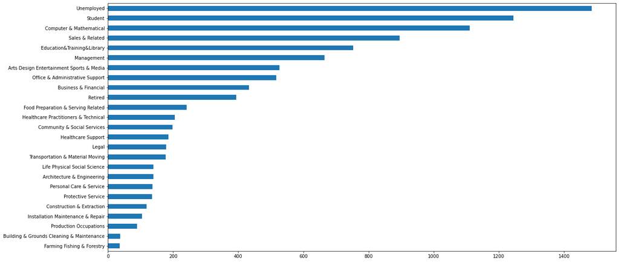

```python
#bar graph for occupation
data_train["occupation"].value_counts().sort_values(ascending=True).plot.barh(figsize=(20,10))
```

```python
# Check the outliers based on coupon usage (With in Y) in occupation
occupation = data_train[data_train['Y']==1]['occupation'].value_counts()
print(occupation.sum())
occupation
```

```
5768
```

```
Unemployed                                   806
Student                                      765
Computer & Mathematical                      638
Sales & Related                              498
Education&Training&Library                   391
Management                                   388
Office & Administrative Support              307
Arts Design Entertainment Sports & Media     280
Business & Financial                         249
Retired                                      184
Food Preparation & Serving Related           144
Healthcare Practitioners & Technical         139
Healthcare Support                           130
Transportation & Material Moving             108
Community & Social Services                   98
Architecture & Engineering                    89
Legal                                         84
Protective Service                            82
Construction & Extraction                     82
Personal Care & Service                       78
Life Physical Social Science                  77
Production Occupations                        56
Installation Maintenance & Repair             54
Building & Grounds Cleaning & Maintenance     22
Farming Fishing & Forestry                    19
Name: occupation, dtype: int64
```

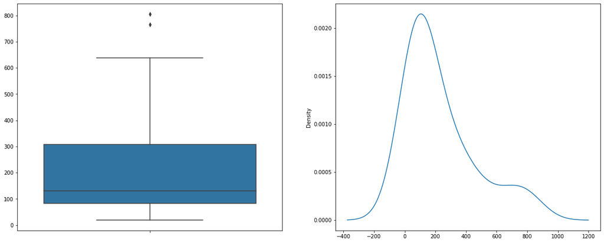

```python
fig, ax = plt.subplots(nrows=1, ncols=2, figsize=(20,8))
sns.boxplot(data=occupation,y=occupation.values, ax=ax[0])
occupation.plot.kde(ax = ax[1])
```

```python
# Removed the Skewness and outliers
occupaton_outlier = ['Unemployed','Student','Computer & Mathematical','Sales & Related','Education&Training&Library',\
                'Management','Office & Administrative Support','Arts Design Entertainment Sports & Media',\
                'Business & Financial','Retired']
data_train['occupation'] = data_train['occupation'].apply(lambda x: 'others' if x not in occupaton_outlier else x)
data_test['occupation'] = data_test['occupation'].apply(lambda x: 'others' if x not in occupaton_outlier else x)

#Reduce Categories and move other occupations to professionals
#occupaton = ['Unemployed','Student']
#data_train['occupation'] = data_train['occupation'].apply(lambda x: 'Professionals' if x not in occupaton else x)
#data_test['occupation'] = data_test['occupation'].apply(lambda x: 'Professionals' if x not in occupaton else x)
data_train.occupation.value_counts()
```

```
others                                      2122
Unemployed                                  1485
Student                                     1245
Computer & Mathematical                     1111
Sales & Related                              896
Education&Training&Library                   753
Management                                   665
Arts Design Entertainment Sports & Media     526
Office & Administrative Support              517
Business & Financial                         433
Retired                                      394
Name: occupation, dtype: int64
```

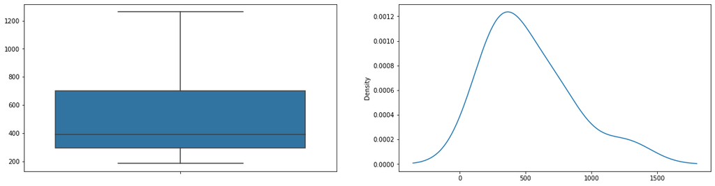

```python
occupation = data_train[data_train['Y']==1]['occupation'].value_counts()
fig, ax = plt.subplots(nrows=1, ncols=2, figsize=(20,5))

sns.boxplot(data=occupation,y=occupation.values, ax=ax[0])
occupation.plot.kde(ax = ax[1])
```

### Deep insight of income

```python
#income has 9 distinct values
data_train["income"].value_counts()
```

```
$25000 - $37499     1622
$12500 - $24999     1464
$37500 - $49999     1444
$100000 or More     1408
$50000 - $62499     1318
Less than $12500     820
$87500 - $99999      712
$75000 - $87499      695
$62500 - $74999      664
Name: income, dtype: int64
```

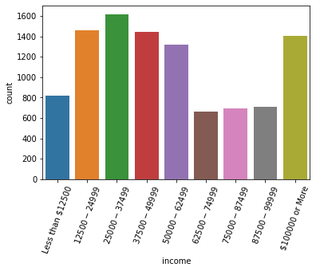

```python
#bar graph for income
income_order = ["Less than $12500", "$12500 - $24999", "$25000 - $37499", "$37500 - $49999", "$50000 - $62499", "$62500 - $74999", "$75000 - $87499", "$87500 - $99999", "$100000 or More"]
chart = sns.countplot(data_train['income'], order = income_order)
chart.set_xticklabels(chart.get_xticklabels(),rotation=70)
plt.figure(figsize=(20,10))
```

```python
# Check the outliers based on coupon usage (With in Y) in income
income = data_train[data_train['Y']==1]['income'].value_counts()
print(income.sum())
income
```

```
5768
```

```
$25000 - $37499     966
$12500 - $24999     848
$100000 or More     822
$37500 - $49999     809
$50000 - $62499     787
Less than $12500    480
$87500 - $99999     371
$62500 - $74999     356
$75000 - $87499     329
Name: income, dtype: int64
```

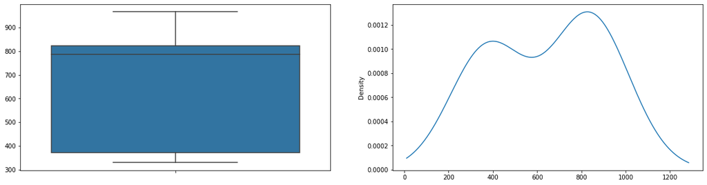

```python
fig, ax = plt.subplots(nrows=1, ncols=2, figsize=(20,5))
sns.boxplot(data=income,y=income.values, ax=ax[0])
income.plot.kde(ax = ax[1])
```

```python
print(income.skew())
```

```
-0.20304477193411624
```

#### **Income doesn;t have outliers, though there exists left skewness

### Deep-Insight of Bar

```python
#Bar has 5 distinct values
data_train["Bar"].value_counts()
```

```
never    4238
less1    2781
1~3      1979
4~8       859
gt8       290
Name: Bar, dtype: int64
```

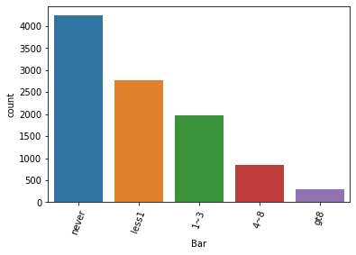

```python
bar_order = ["never", "less1", "1~3", "4~8", "gt8"]
chart = sns.countplot(data_train['Bar'], order = bar_order)
chart.set_xticklabels(chart.get_xticklabels(),rotation=70)
plt.figure(figsize=(10,5))
```

### Deep-Insight of CoffeeHouse

```python
#CoffeeHouse has 5 distinct values
data_train["CoffeeHouse"].value_counts()
```

```
less1    2868
1~3      2586
never    2375
4~8      1423
gt8       895
Name: CoffeeHouse, dtype: int64
```

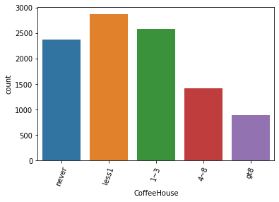

```python
CoffeeHouse_order = ["never", "less1", "1~3", "4~8", "gt8"]
chart = sns.countplot(data_train['CoffeeHouse'], order = CoffeeHouse_order)
chart.set_xticklabels(chart.get_xticklabels(),rotation=70)
plt.figure(figsize=(10,5))
```

### Deep-Insight of CarryAway

```python
#CarryAway has 5 distinct values
data_train["CarryAway"].value_counts()
```

```
1~3      3863
4~8      3416
less1    1485
gt8      1263
never     120
Name: CarryAway, dtype: int64
```

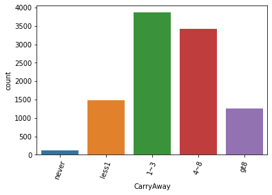

```python
CarryAway_order = ["never", "less1", "1~3", "4~8", "gt8"]
chart = sns.countplot(data_train['CarryAway'], order = CarryAway_order)
chart.set_xticklabels(chart.get_xticklabels(),rotation=70)
plt.figure(figsize=(10,5))
```

### Deep-Insight of RestaurantLessThan20

```python
#RestaurantLessThan20 has 5 distinct values
data_train["RestaurantLessThan20"].value_counts()
```

```
1~3      4393
4~8      2868
less1    1688
gt8      1025
never     173
Name: RestaurantLessThan20, dtype: int64
```

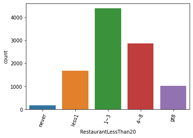

```python
RestaurantLessThan20_order = ["never", "less1", "1~3", "4~8", "gt8"]
chart = sns.countplot(data_train['RestaurantLessThan20'], order = RestaurantLessThan20_order)
chart.set_xticklabels(chart.get_xticklabels(),rotation=70)
plt.figure(figsize=(10,5))
```

### Deep-Insight of Restaurant20To50

```python
#Restaurant20To50 has 5 distinct values
data_train["Restaurant20To50"].value_counts()
```

```
less1    5037
1~3      2622
never    1693
4~8       579
gt8       216
Name: Restaurant20To50, dtype: int64
```

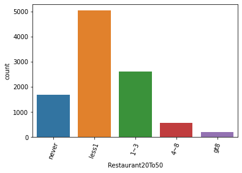

```python
Restaurant20To50_order = ["never", "less1", "1~3", "4~8", "gt8"]
chart = sns.countplot(data_train['Restaurant20To50'], order = Restaurant20To50_order)
chart.set_xticklabels(chart.get_xticklabels(),rotation=70)
plt.figure(figsize=(10,5))
```

## Outlier analysis

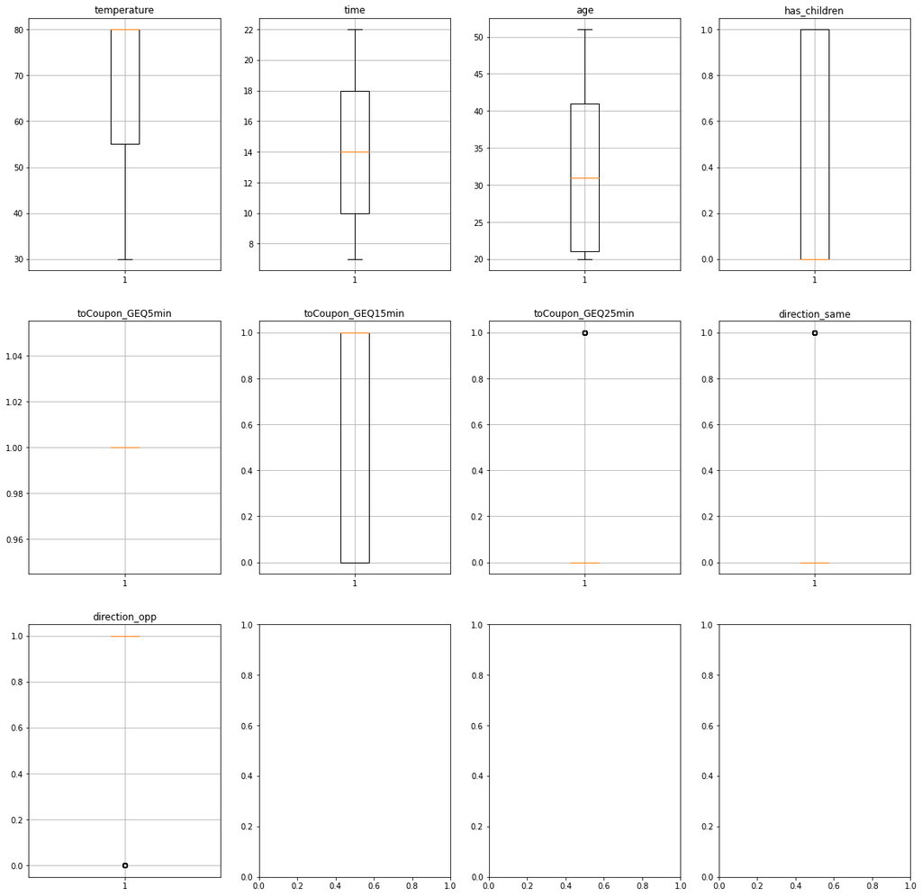

```python
#Features with Outliers
col_dict = {'temperature':1,'time':2,'age':3,'has_children':4,'toCoupon_GEQ5min':5,'toCoupon_GEQ15min':6,'toCoupon_GEQ25min':7,'direction_same':8,'direction_opp':9}

# Detect outliers in each variable using box plots.
fig, ax = plt.subplots(nrows=3, ncols=4, figsize=(20,20))

for variable,i in col_dict.items():
    row = (i - 1) //4
    col = (i + 3) % 4
    #print(variable, i, row, col)
    ax[row, col].boxplot(data_train[variable])
    ax[row, col].set_title(variable)
    ax[row, col].grid()
```

```python
#Features with Outliers
numcol = ['temperature','time','age','has_children','toCoupon_GEQ5min','toCoupon_GEQ15min','toCoupon_GEQ25min','direction_same','direction_opp']
for column in numcol:
    if data_train[column].quantile(.9973)<data_train[column].max():
        print(column)
        print('99th Percentile',data_train[column].quantile(.9973))
        print('Max',data_train[column].max())
        print('Outliers Present in Column {}'.format(column))
        print('')
    elif data_train[column].quantile(0)>data_train[column].min():
        print(column)
        print('99th Percentile',data_train[column].quantile(.9973))
        print('Min',data_train[column].min())
        print('Outliers Present in Column {}'.format(column))
        print('')
    else:
        print('NO Outliers Present in Column {}'.format(column))
```

```
NO Outliers Present in Column temperature
NO Outliers Present in Column time
NO Outliers Present in Column age
NO Outliers Present in Column has_children
NO Outliers Present in Column toCoupon_GEQ5min
NO Outliers Present in Column toCoupon_GEQ15min
NO Outliers Present in Column toCoupon_GEQ25min
NO Outliers Present in Column direction_same
NO Outliers Present in Column direction_opp
```